# Лабораторная работа №4

Модель гармонических колебаний

Гаглоев Олег Мелорович.

Российский университет дружбы народов, Москва, Россия

4 марта 2023

# Информация

## Докладчик

- Гаглоев Олег Мелорович
- студент уч. группы НПИбд-01-20
- Российский университет дружбы народов
- 1032201347@pfur.ru
- https://github.com/SimpleOG?tab=repositories

# Вводная часть

## Актуальность

- Математика всегда полезна для ума

## Объект и предмет исследования

- Модель гармонических колебаний
- Языки для моделирования:
  - Julia
  - OpenModelica

## Цели и задачи

- Построить фазовый портрет гармонического осциллятора и решение уравнения гармонического осциллятора для трех случаев:
  - Колебания гармонического осциллятора без затуханий и без действий внешней силы
  - Колебания гармонического осциллятора c затуханием и без действий внешней силы
  - Колебания гармонического осциллятора c затуханием и под действием внешней силы
- Выполнить задачу на заданном интервале

## Материалы и методы

- Языки для моделирования:
  - Julia
  - OpenModelica

# Выполнение работы

## Теория

$$\ddot x(t) + a\dot x(t) + bx = F(t)$$
$$\begin{aligned}
y = \frac{dx}{dt} = \dot x(t)
\\
\frac{d^2x}{dt^2} = \frac{dy}{dt}
\\
\frac{dy}{dt} + ay(t) + bx(t) = 0
\end{aligned}$$
$$\begin{cases}
\frac{dx}{dt} = y
\\
\frac{dy}{dt} = -ay - bx
\end{cases}$$

## Условие модели №1

- Колебания гармонического осциллятора без затуханий и без действий внешней силы

$$\ddot x +21x=0$$

## Теория модели №1

Общий вид первого случая: $\ddot x + wx = 0$, где *w* = *ω*<sub>0</sub><sup>2</sup> = 21.

Тогда система ОДУ первого порядка для решения задачи:

$$\begin{cases}
\dot x = y
\\
\dot y = -21x
\end{cases}$$

## Условие модели №2

- Колебания гармонического осциллятора c затуханием и без действий внешней силы

$$\ddot x + \dot 2.2x +2.3x = 0$$

## Теория модели №2

Тогда система ОДУ первого порядка для решения задачи:

$$\begin{cases}
\dot x = y
\\
\dot y = -2.2y -2.3x
\end{cases}$$

## Условие модели №3

- Колебания гармонического осциллятора c затуханием и под действием внешней силы $\ddot x + \dot 2.4x +2.5x = 0.2\sin(2.6t)$

## Теория модели №3

Общий вид третьего случая: $\ddot x + gy + wx = F(t)$, где *g* = 2*γ* = 2.4, *w* = *ω*<sub>0</sub><sup>2</sup> = 2.5 и *F*(*t*) = 0.2sin (2.6*t*).

Тогда система ОДУ первого порядка для решения задачи:

$$\begin{cases}
\dot x = y
\\
\dot y = 0.2\sin(2.6t) -2.4y -2.5x
\end{cases}$$

## Код на Julia

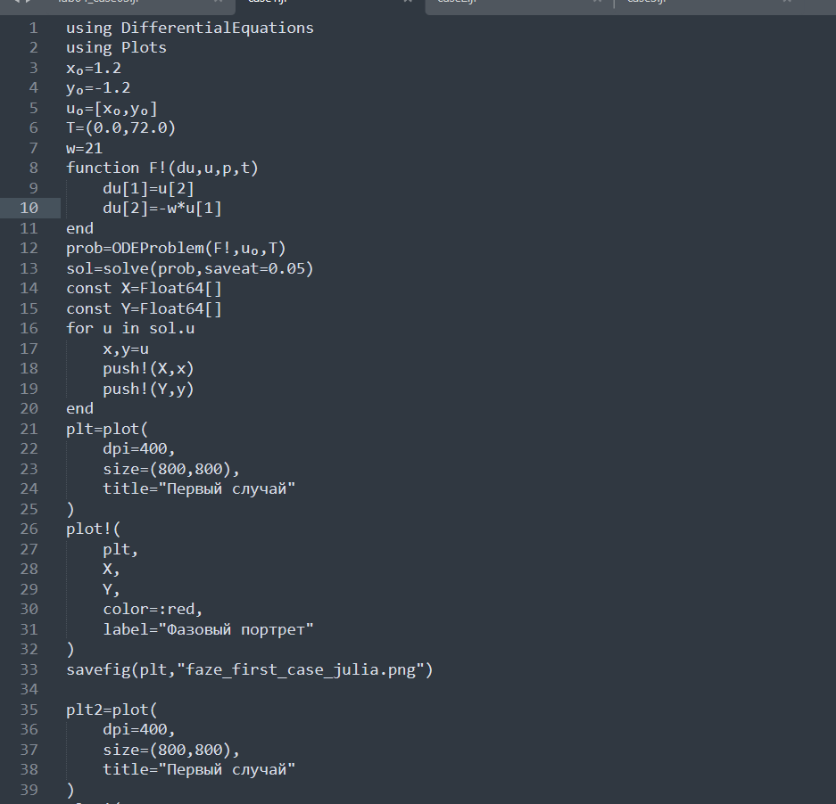

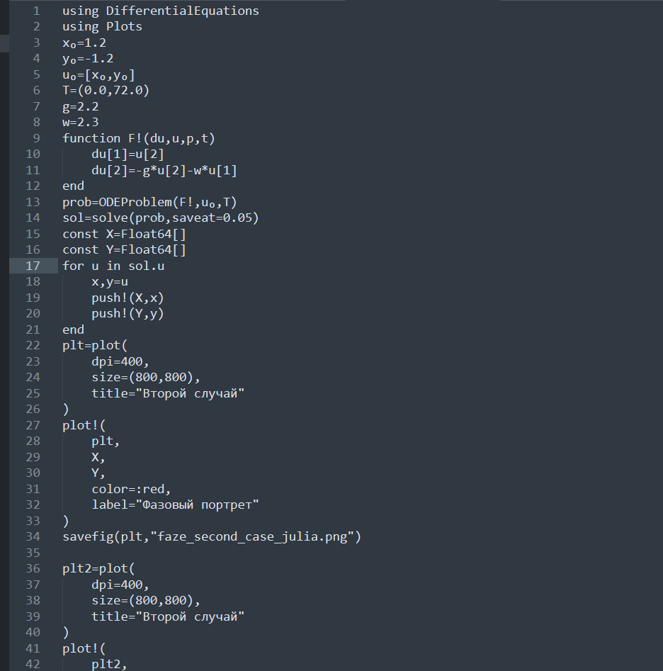

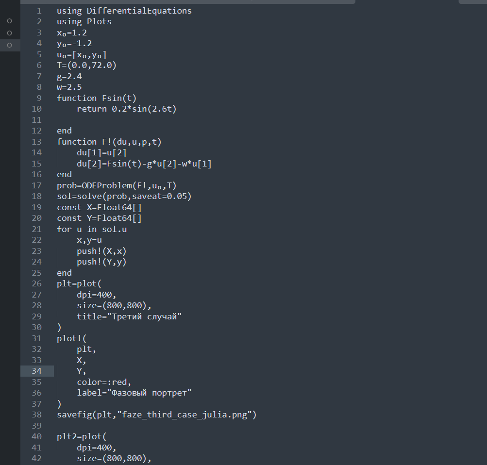

## Код на OpenModelica

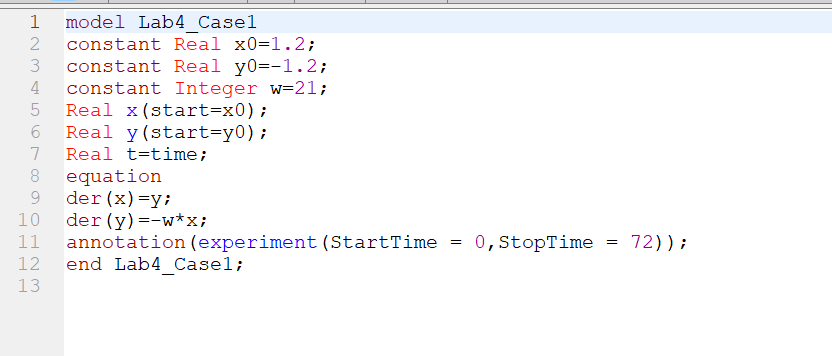

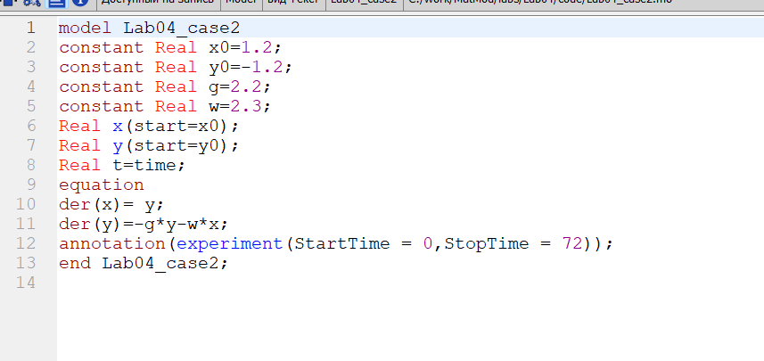

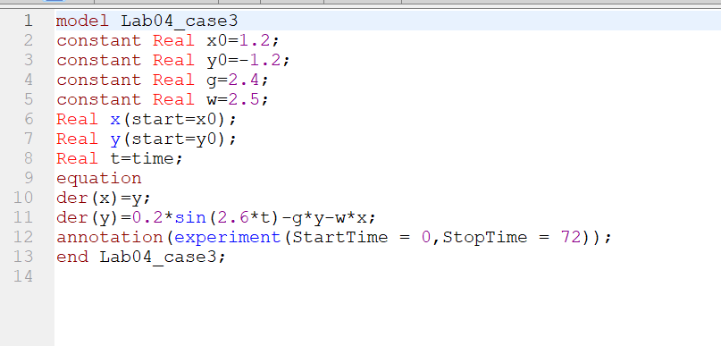

## Графики Julia - случай 1

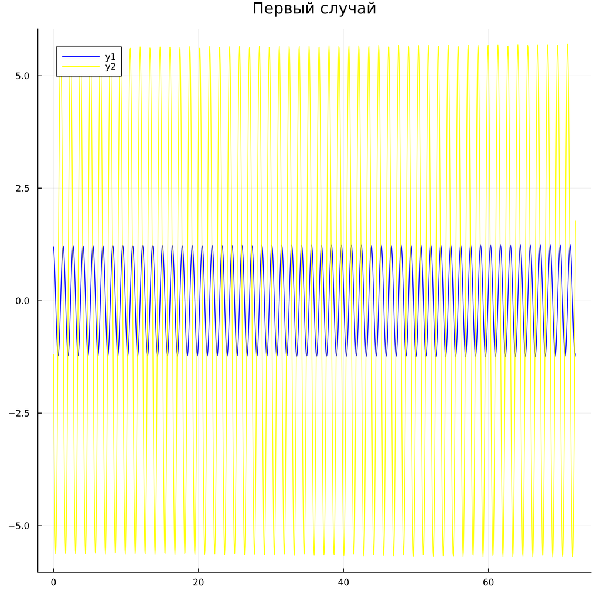

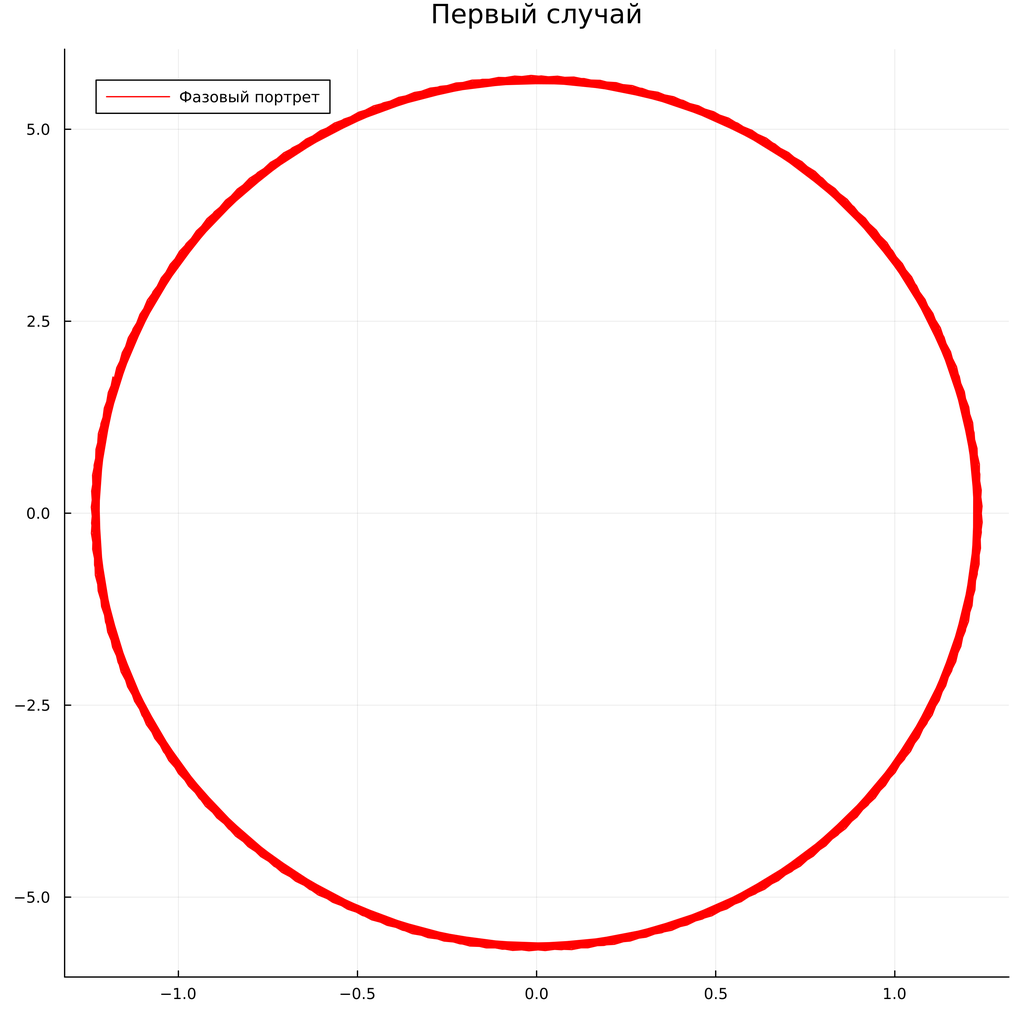

## Графики OpenModelica - случай 1

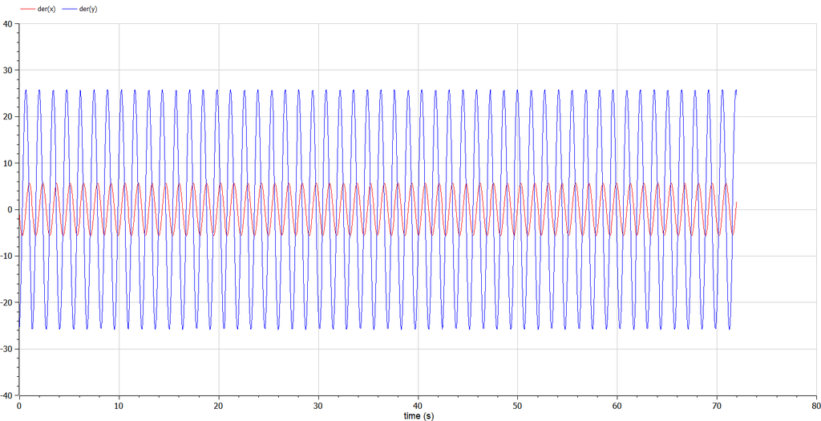

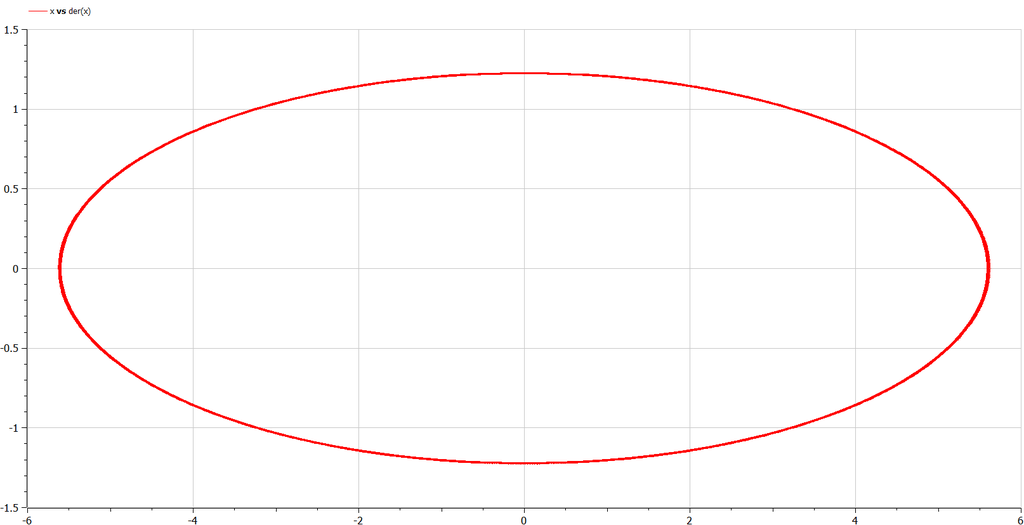

## Графики Julia - случай 2

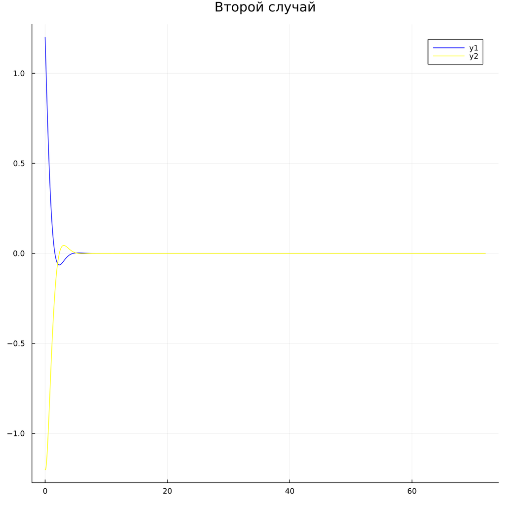

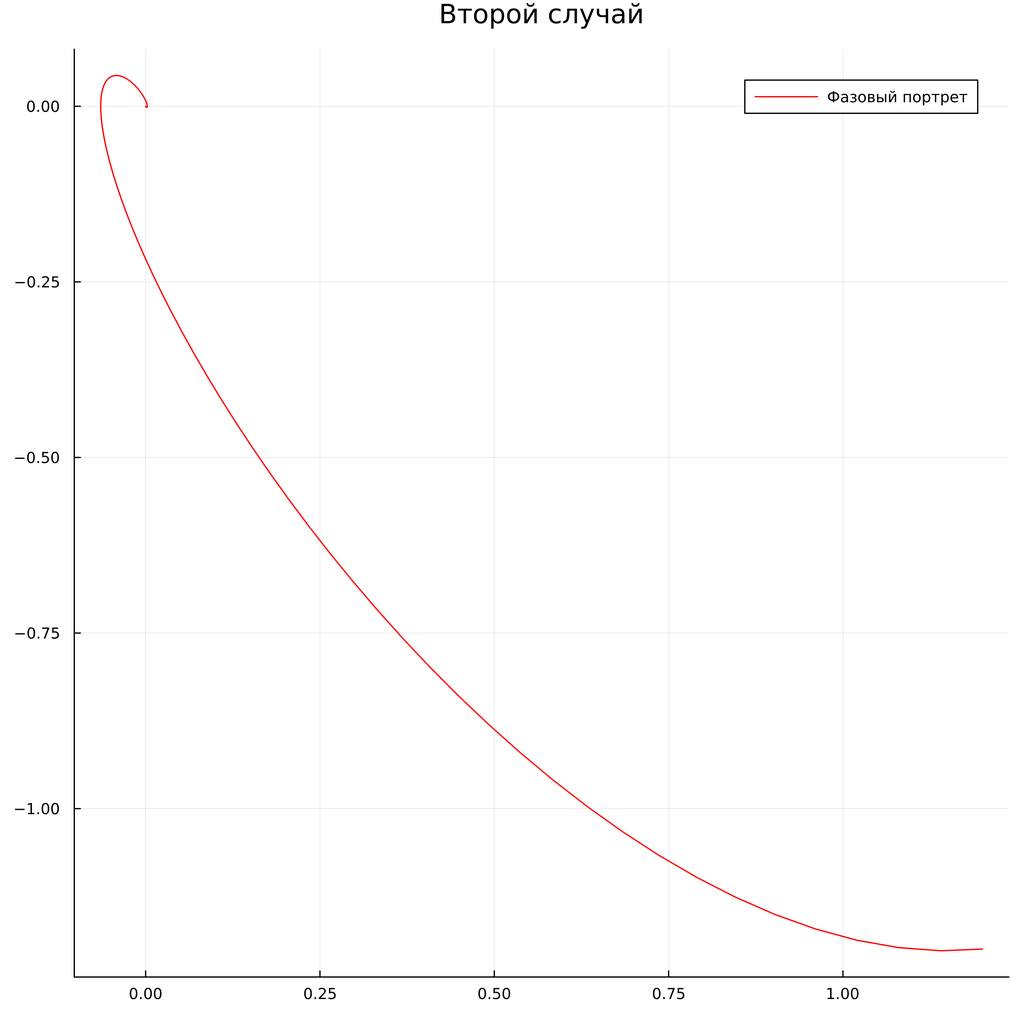

## Графики OpenModelica - случай 2

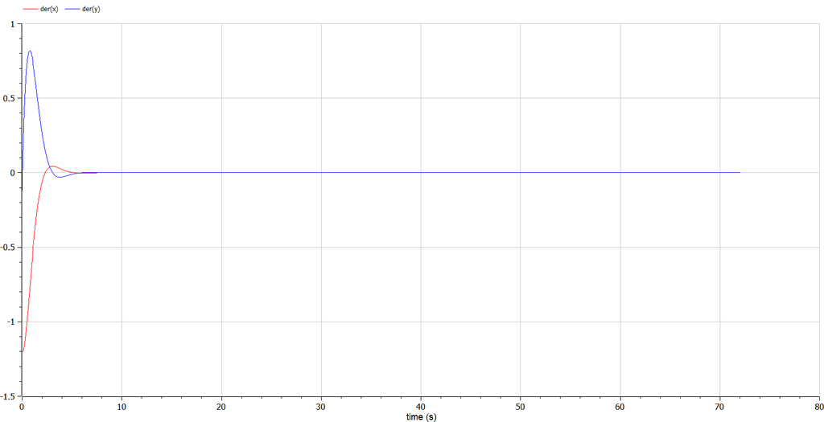

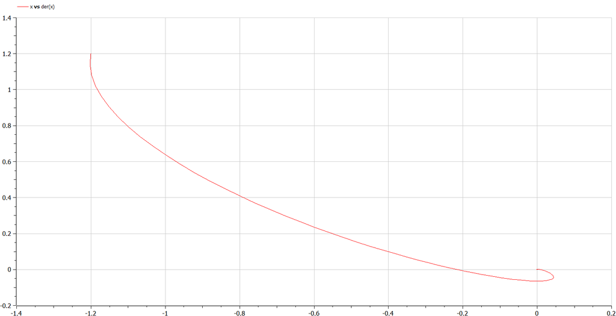

## Графики Julia - случай 3

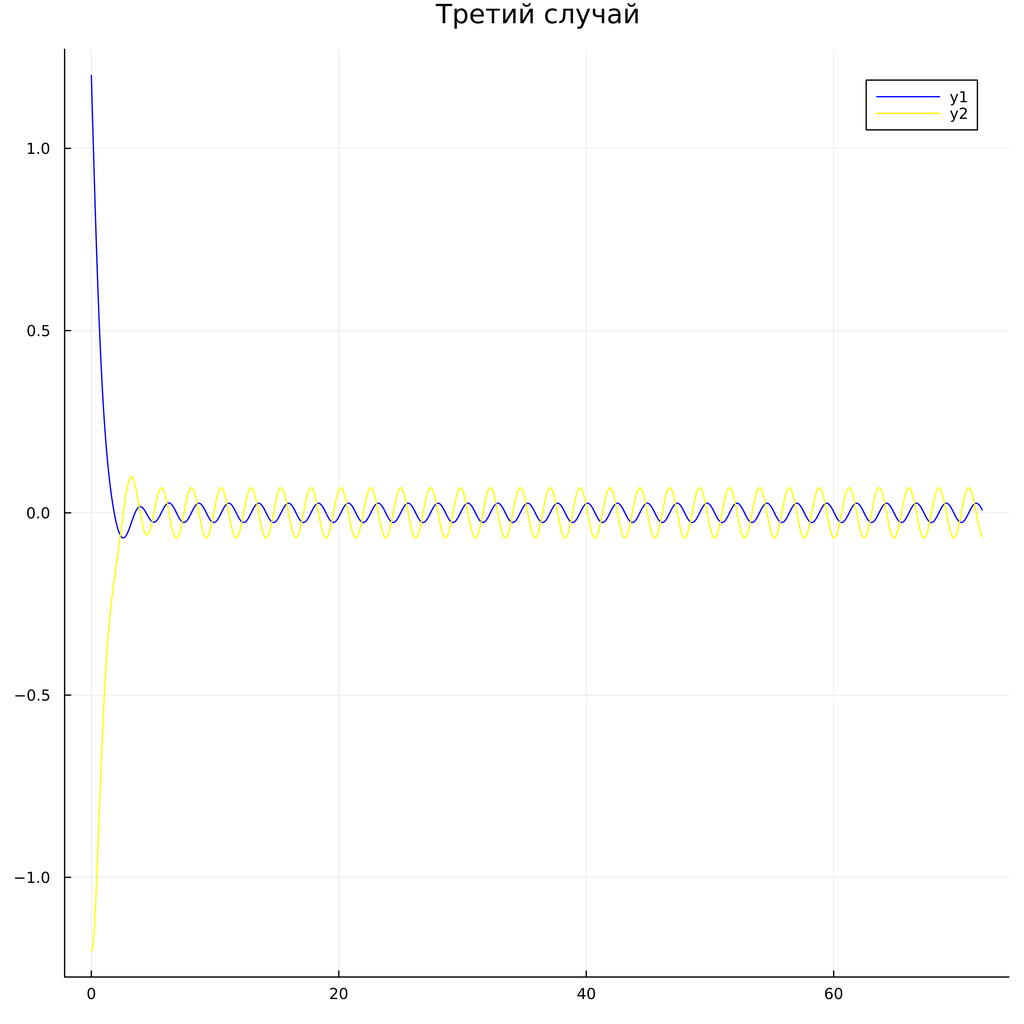

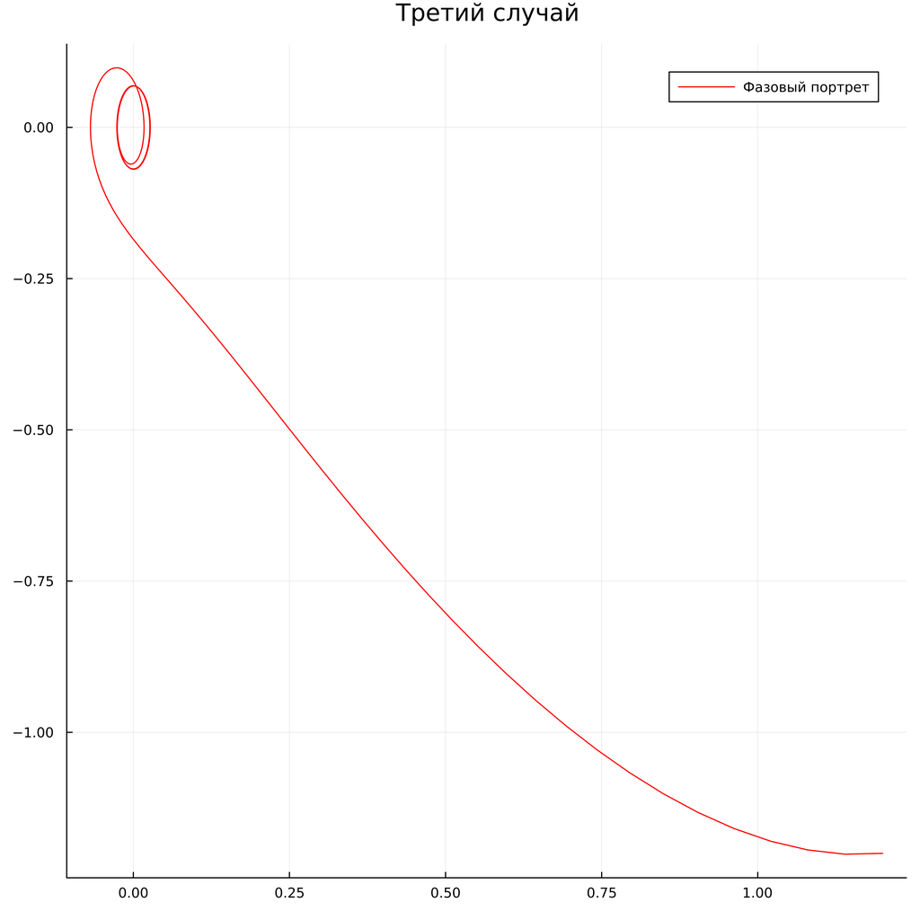

## Графики OpenModelica - случай 3

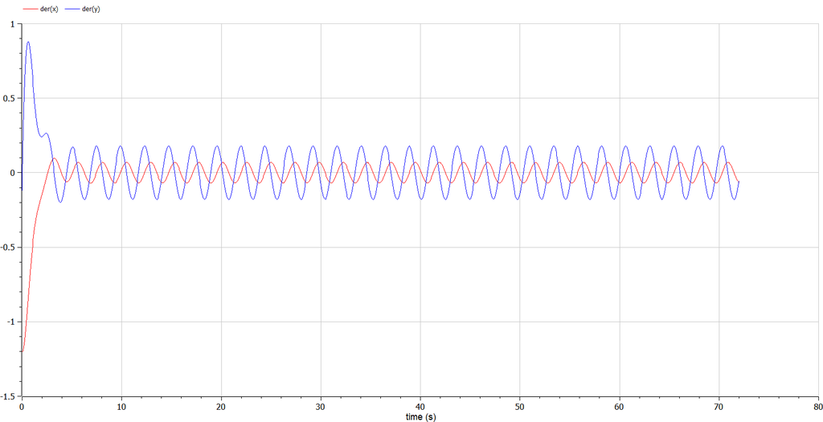

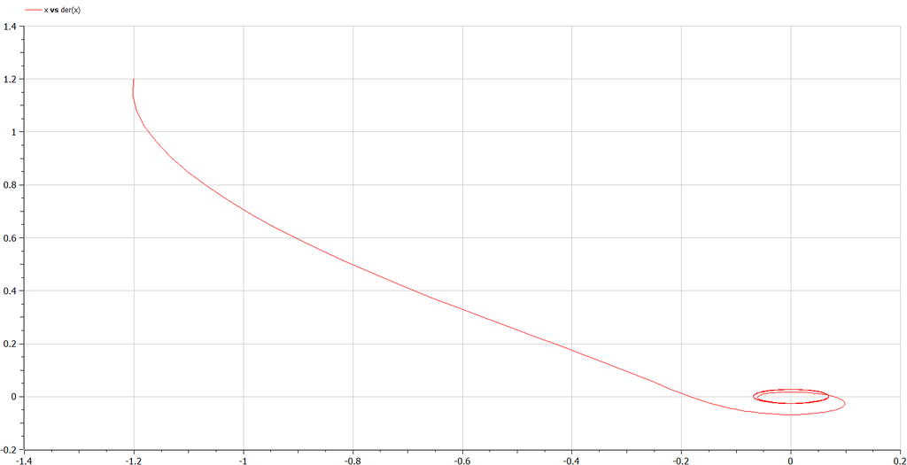

# Результаты работы

- Мы построили фазовый портрет гармонического осциллятора и решение уравнения гармонического осциллятора для трех случаев:
  - Колебания гармонического осциллятора без затуханий и без действий внешней силы
  - Колебания гармонического осциллятора c затуханием и без действий внешней силы
  - Колебания гармонического осциллятора c затуханием и под действием внешней силы
- Выполнили задачу на заданном интервале

# Вывод

Я создал модель гармонический колебаний по средствам языков Julia и OpenModelica.